# Tree based regression

Mirco Bazzani

12/6/2020

### Data handling

We take the datasets we’ve already created. I’ve included the data imputation, but am not completely sure if we are going no need that.

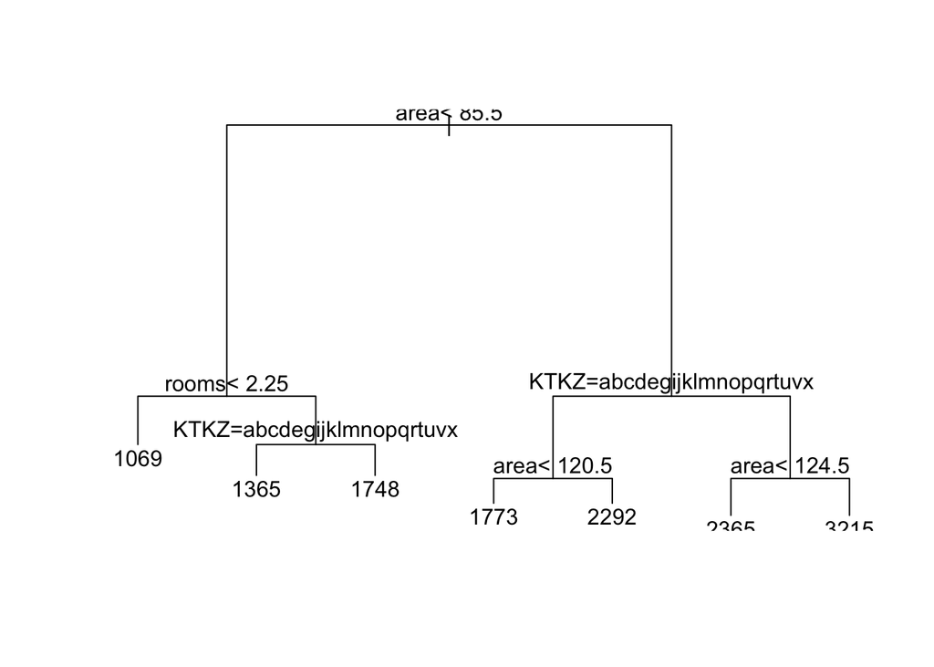

```r
fit_tree <- rpart(rent_full ~ . ,
                  method = "anova",
                  data = X_t_train)

plot(fit_tree)
text(fit_tree)
```

```r
rsq.rpart(fit_tree) #Increase of R2 per split vs decrease relative error per split
```

```
##
## Regression tree:
## rpart(formula = rent_full ~ ., data = X_t_train, method = "anova")
##
## Variables actually used in tree construction:
## [1] area  KTKZ  rooms
##
## Root node error: 3.115e+10/67502 = 461471
##
## n= 67502
##
##         CP nsplit rel error  xerror      xstd
## 1 0.287062      0   1.00000 1.00003 0.0102360
## 2 0.087053      1   0.71294 0.71239 0.0077972
## 3 0.051101      2   0.62589 0.62672 0.0066827
## 4 0.038975      3   0.57478 0.57556 0.0066035
## 5 0.032624      4   0.53581 0.53800 0.0059121
## 6 0.026175      5   0.50319 0.50549 0.0057809
## 7 0.010000      6   0.47701 0.47897 0.0053899
```

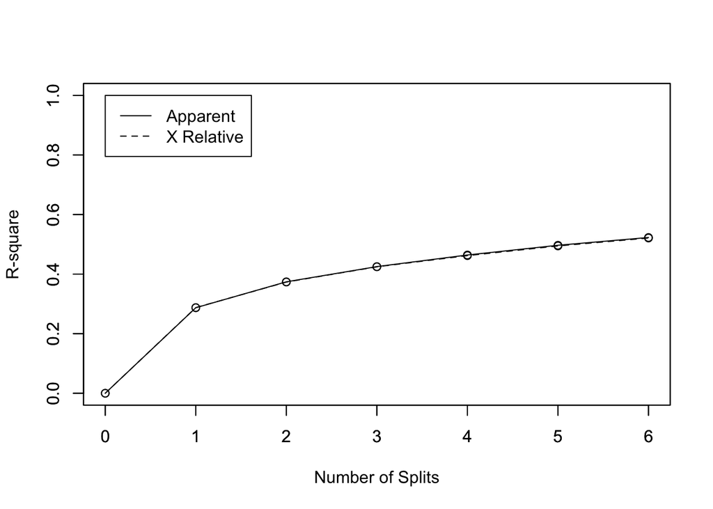

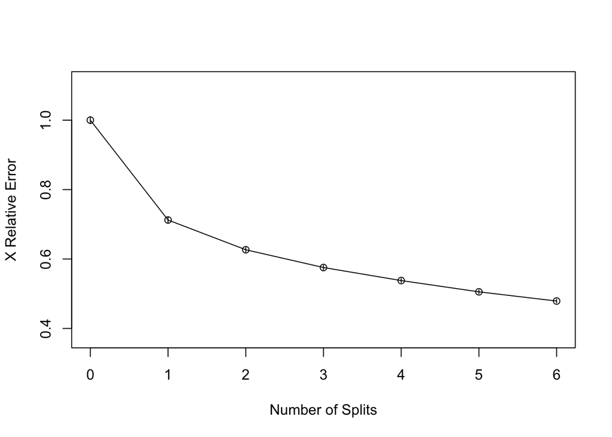

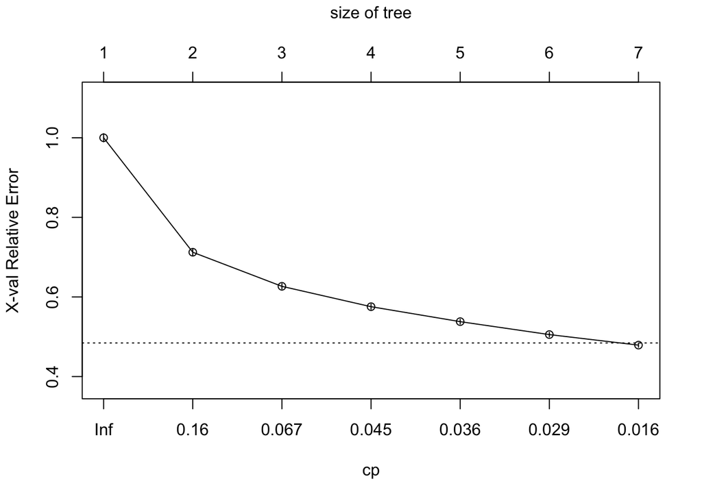

```r
plotcp(fit_tree) #Complexity Parameter of the Tree. The model goes with 6 splits as the optimum.
```

Let’s look if we can prune the tree in order to get a better estimation:

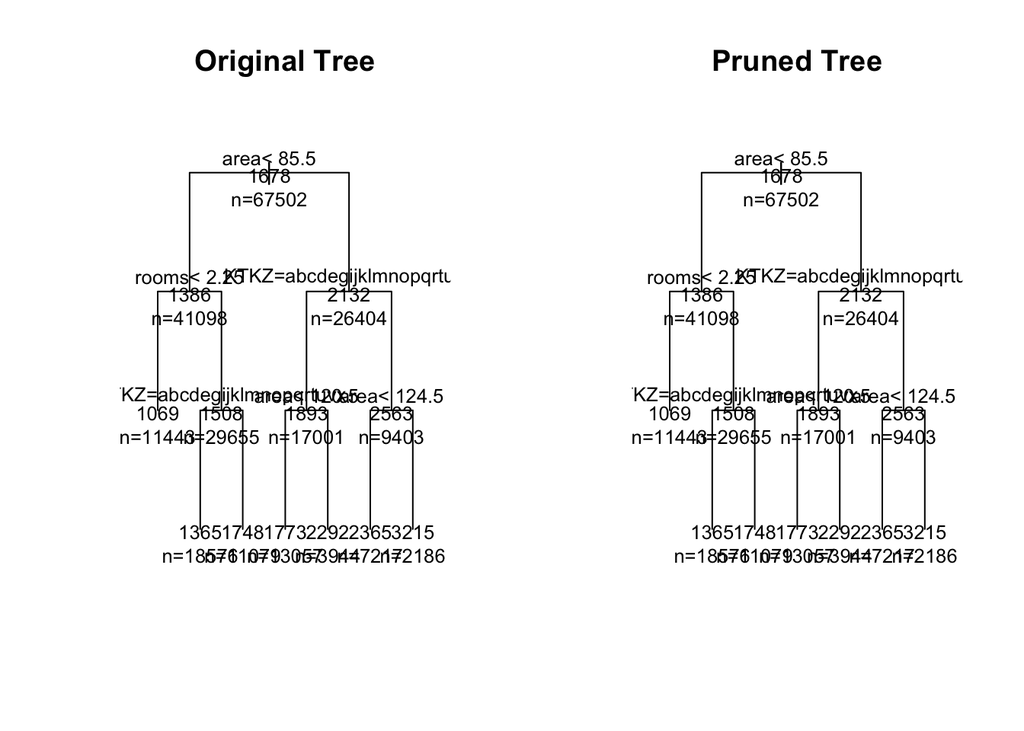

```r
pruned_tree <- prune(fit_tree, cp = fit_tree$cptable[which.min(fit_tree$cptable[, "xerror"]), "CP"])

par(mfrow = c(1, 2)) # Two Plots

plot(fit_tree, uniform = TRUE, margin = 0.1, main = "Original Tree")
text(fit_tree, use.n = TRUE, all = TRUE, cex = 0.8)
plot(pruned_tree, uniform = TRUE, margin = 0.1, main = "Pruned Tree")
text(pruned_tree, use.n = TRUE, all = TRUE, cex = 0.8)
```

No, the base model already produced the optimal tree. Let’s make a prediction!

```r
predictions_tree <- predict(pruned_tree, X_t_test)
output <- data.frame(Y_t_test$rent_full, predictions_tree)

RMSE(output$Y_t_test.rent_full,output$predictions_tree)
```

```
## [1] 465.3641
```

We’ve got even worse predictions than with our Lasso-Regression!

Let’s try it again, but with our imputed dataset:

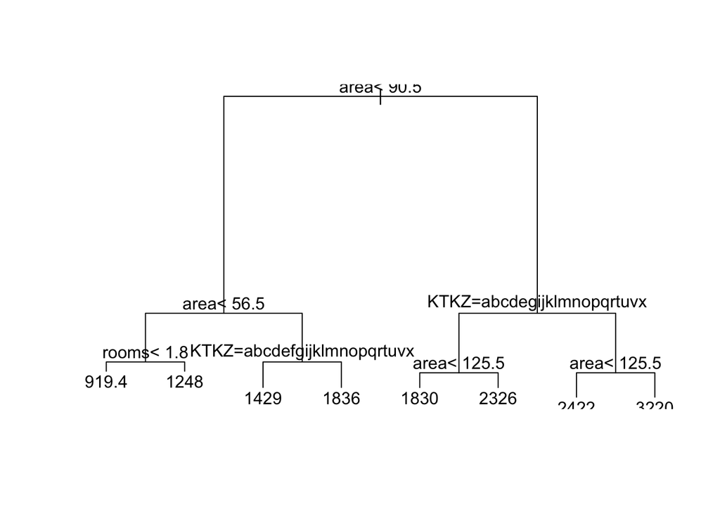

```r
X_t_i <- complete_set

set.seed(123)

#Normalizing data
#processed <- preProcess(X, method = c("center", "scale"))
#X <- predict(processed, X)


index <- createDataPartition(X_t_i$rent_full, p=0.75, list=FALSE)

X_t_train_i <- X_t_i[index,1:27]
X_t_test_i <- X_t_i[-index,2:27 ]
Y_t_test_i <-X_t_i[-index,1]


fit_tree_i <- rpart(rent_full ~ . ,
                  method = "anova",
                  data = X_t_train_i)

plot(fit_tree_i)
text(fit_tree_i)
```

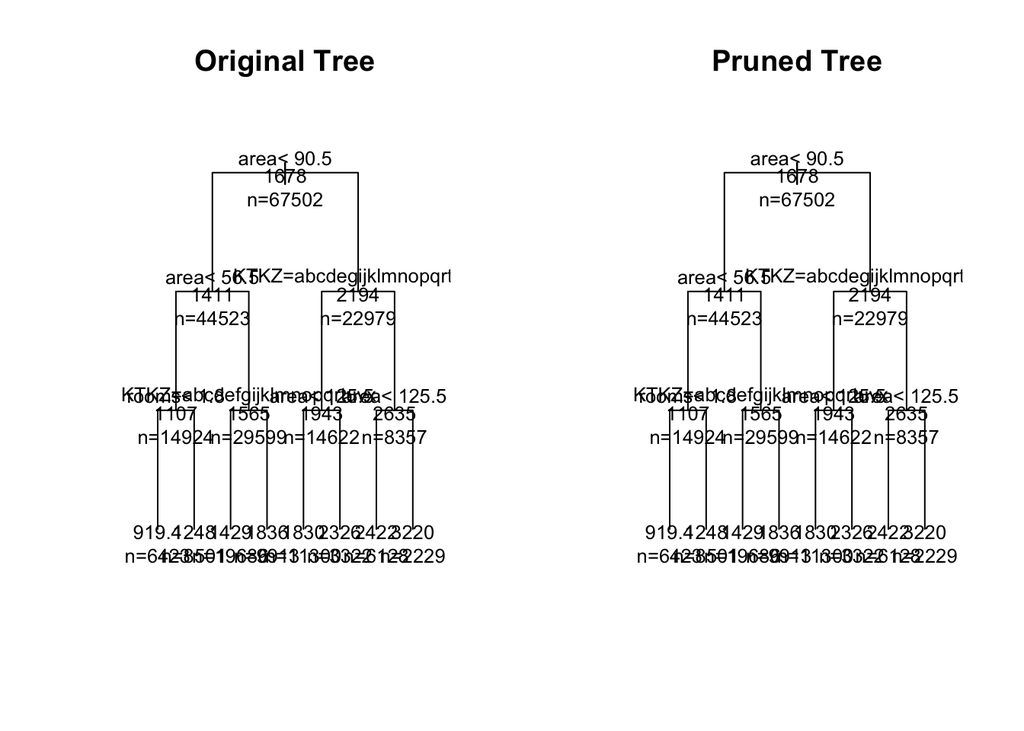

```r
pruned_tree_i <- prune(fit_tree_i, cp = fit_tree_i$cptable[which.min(fit_tree_i$cptable[, "xerror"]), "CP"])

par(mfrow = c(1, 2)) # Two Plots

plot(fit_tree_i, uniform = TRUE, margin = 0.1, main = "Original Tree")
text(fit_tree_i, use.n = TRUE, all = TRUE, cex = 0.8)
plot(pruned_tree_i, uniform = TRUE, margin = 0.1, main = "Pruned Tree")
text(pruned_tree_i, use.n = TRUE, all = TRUE, cex = 0.8)
```

```r
predictions_tree_i <- predict(pruned_tree_i, X_t_test_i)
output_i <- data.frame(Y_t_test_i, predictions_tree_i)

RMSE(output_i$Y_t_test_i,output_i$predictions_tree_i)
```

```
## [1] 458.6443
```

Slightly better, but still not overwhelming.

Trees that are based on information Gain (the standard Trees I’ve used so far) don’t do the trick. I’ll swap to **Conditional Inference Trees**,

```r
library(party)
fit_ctree <- ctree(formula = rent_full ~ ., data = X_t_train_i)

prediction_ctree <- predict(fit_ctree, X_t_test_i)

output_ctree <- data.frame(prediction_ctree, Y_t_test_i)

RMSE(output_ctree$rent_full,output_ctree$Y_t_test_i)
```

```
## [1] 388.3488
```

The conditional trees work as follows:

*“ctree, according to its authors (see chl’s comments) avoids the following variable selection bias of rpart (and related methods): They tend to select variables that have many possible splits or many missing values. Unlike the others, ctree uses a significance test procedure in order to select variables instead of selecting the variable that maximizes an information measure (e.g. Gini coefficient).”*

As we can see, they are better at predicting the housing prices than all of my other models.

## Random forest

ctrees worked pretty good, but I still want to try random forests.

Let’s look at the data:

```r
library(randomForest)
set.seed(4900)

fit_randomf <- randomForest(x=X_t_train_i[,2:27], y = X_t_train_i[,1], ntree = 50)

prediction_randomf <- predict(fit_randomf, X_t_test_i)

output_randomf <- data.frame(prediction_randomf, Y_t_test_i)

RMSE(output_randomf$prediction_randomf,output_randomf$Y_t_test_i)
```

```
## [1] 333.6834
```

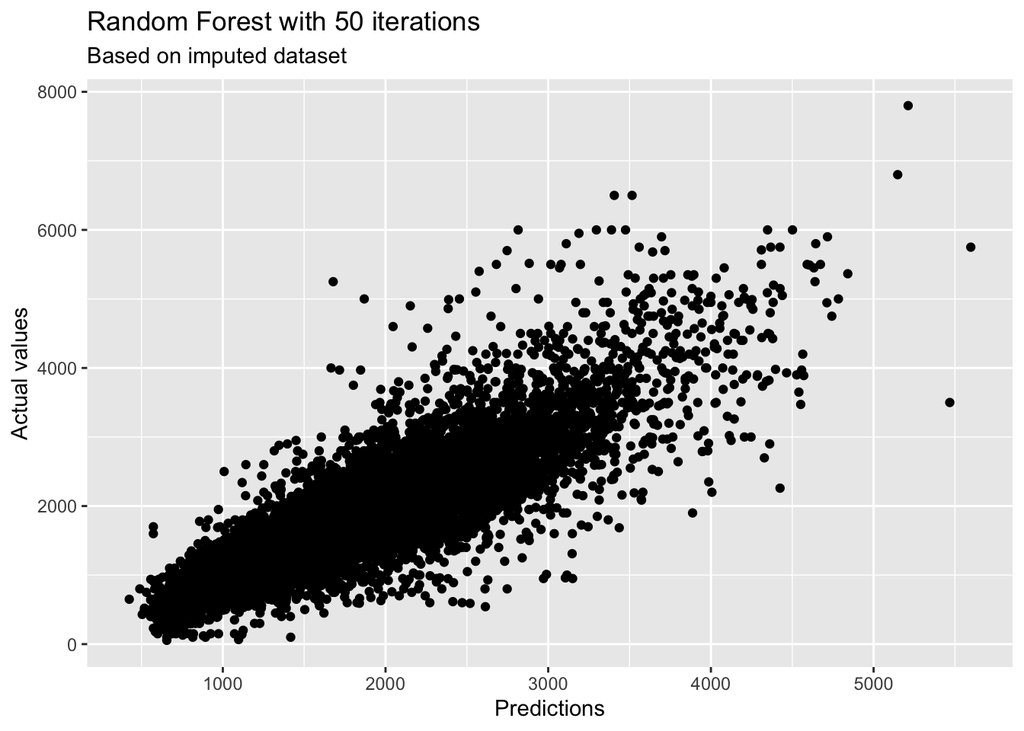

```r
ggplot(output_randomf, aes(prediction_randomf,Y_t_test_i)) +
  geom_point() +
  labs(title = "Random Forest with 50 iterations",
       subtitle = "Based on imputed dataset") +
  xlab("Predictions") +
  ylab("Actual values")
```